# R Notebook

```r
#load necessary libraries
library(dplyr)
library(readxl)
library(ggplot2)
library(ggpubr)
library(qqplotr)
#library(car)
library(e1071)
library(nortest)
library(BSDA)
```

# 7.38

## Potential insurance fraud

```r
file_name = "ex07-38jocko.xls"
df = read_xls(file_name)
df
```

| Car | Jocko | Other |
| --- | --- | --- |
| 1 | 1410 | 1250 |
| 2 | 1550 | 1300 |
| 3 | 1250 | 1250 |
| 4 | 1300 | 1200 |
| 5 | 900 | 950 |
| 6 | 1520 | 1575 |
| 7 | 1750 | 1600 |
| 8 | 3600 | 3380 |
| 9 | 2250 | 2125 |
| 10 | 2840 | 2600 |

## A) Solution:

```r
df$difference = df$Jocko-df$Other
df
```

| Car | Jocko | Other | difference |
| --- | --- | --- | --- |
| 1 | 1410 | 1250 | 160 |
| 2 | 1550 | 1300 | 250 |
| 3 | 1250 | 1250 | 0 |
| 4 | 1300 | 1200 | 100 |
| 5 | 900 | 950 | -50 |
| 6 | 1520 | 1575 | -55 |
| 7 | 1750 | 1600 | 150 |
| 8 | 3600 | 3380 | 220 |
| 9 | 2250 | 2125 | 125 |
| 10 | 2840 | 2600 | 240 |

```r
# mean of the differences
mean(df$difference)
```

```
[1] 114
```

```r
# standard deviation of the difference
sd(df$difference)
```

```
[1] 114.4018
```

## B) Solution:

*Null Hypothesis H0: µd = 0* *Alternate hypothesis Ha: µd <> 0*

```r
# Here
u0 = 0
xbar = mean(df$difference)
S = sd(df$difference)
n = length(df$Car) # sample size
n
```

```
[1] 10
```

```r
# degree of freedom
d_f = n-1
d_f
```

```
[1] 9
```

```r
# T-value for paired t test
t = (xbar-u0)/(S/sqrt(n))
t
```

```
[1] 3.15117
```

```r
# P-value of a two-tailed test
2*pt(t, d_f, lower.tail = FALSE)
```

```
[1] 0.01171546
```

```r
# Test statistics for a paired t test
t_test = t.test(df$Jocko,df$Other,paired=TRUE,alternative="two.sided", conf.level = .95)
t_test
```

```
    Paired t-test

data:  df$Jocko and df$Other
t = 3.1512, df = 9, p-value = 0.01172
alternative hypothesis: true difference in means is not equal to 0
95 percent confidence interval:
  32.16186 195.83814
sample estimates:
mean of the differences
                    114
```

*So, we can reject the null hypothesis as the p-value is less than the 5% level of significance. There us sufficient evidence to indicate tat there is a difference between Jocko’s garage and other garage. The result is statistically significant.*

## C) Solution:

```r
# 95% confidence interval for the difference in estimates
t_test[4]
```

```
$conf.int
[1]  32.16186 195.83814
attr(,"conf.level")
[1] 0.95
```

## D) Solution:

*Using part (c) confidence level intervals, I would recommend the insurance company to seek for a repayment amount between $32.16 and $195.84.*

# 7.71

## Sadness and spending

```r
file_name = "ex07-71sadness.xls"
df = read_xls(file_name, range = 'A1:B32')
df
```

| Price | Group |
| --- | --- |
| 1.0 | S |
| 2.5 | S |
| 0.0 | N |
| 1.0 | N |
| 2.0 | N |
| 0.0 | N |
| 3.0 | S |
| 4.0 | S |
| 0.0 | N |
| 0.0 | N |

[output cut: 21 more lines]

```r
summary(df)
```

```
     Price          Group
 Min.   :0.000   Length:31
 1st Qu.:0.250   Class :character
 Median :1.000   Mode  :character
 Mean   :1.419
 3rd Qu.:2.250
 Max.   :4.000
```

#### Function to recreate Minitab Normal Probability Plot in R (Source: http://aleph-nought.blogspot.com/2013/03/solved-recreate-minitab-normal.html)

```r
minitab_normal_prob_plot <- function(data, x_label) {

    # The labels for the y-axis, corresponding to percentiles

    y_axis_labels = c(1,5,10,20,30,40,50,60,70,80,90,95,99)

    # Lengths, mean, and sd of data

    n = length(data)
    my_mean = mean(data)
    my_sd = sd(data)

    ### Set up the y-axis values

    # Translate labels to decimal percentages

    percentages = y_axis_labels / 100

    # Convert percentages to z-values and shift so that all values are >= 0

    y_axis_points = qnorm(percentages)
    y_shift = y_axis_points[1]
    y_axis_points = y_axis_points - y_shift

    # The minimum and maximum y values

    y_min = y_axis_points[1]
    y_max = y_axis_points[length(y_axis_points)]

    ### Calculate the main data set
    # x and y values per http://en.wikipedia.org/wiki/Normal_probability_plot.

    x_data_points = sort(data)

    data_percents = c()
    for(i in 1:n) {
        if (i == 1) {
            data_percents[i] = 1 - 0.5^(1/n)
        } else if (i == n) {
            data_percents[i] = 0.5^(1/n)
        } else {
            data_percents[i] = (i - 0.3175)/(n+0.365)
        }
    }

    ### Trend line calculation
    # Project a line represented expected distribution values on assumption
    # that data is normal.

    trend_x0 = qnorm(percentages[1], mean = my_mean, sd = my_sd)
    trend_x1 = qnorm(
            percentages[length(percentages)], mean = my_mean, sd = my_sd
    )

    # Convert percents to z-values and shift as before

    y_data_points = qnorm(data_percents) - y_shift

    ### Set up the envelope
    # Stolen from
    # http://stackoverflow.com/questions/3929611/recreate-minitab-normal-probability-plot

    library(MASS)
    qprobs<-qnorm(percentages)
    fd<-fitdistr(data, "normal") #Maximum-likelihood Fitting of Univariate Dist from MASS
    xp_hat<-fd$estimate[1]+qprobs*fd$estimate[2]  #estimated perc. for the fitted normal
    v_xp_hat<- fd$sd[1]^2+qprobs^2*fd$sd[2]^2+2*qprobs*fd$vcov[1,2] #var. of estimated perc
    xpl<-xp_hat + qnorm(0.025)*sqrt(v_xp_hat)  #lower bound
    xpu<-xp_hat + qnorm(0.975)*sqrt(v_xp_hat)  #upper bound

    ### Set up the x-axis

    x_min = min(c(data, trend_x0, trend_x1, xpl, xpu))
    x_max = max(c(data, trend_x0, trend_x1, xpl, xpu))

    ### Plot it all

    # Data set. Points plotted twice due to keep them from getting clobbered by
    # white rectangle.
    par(bg = "beige")
    plot(
        x_data_points, y_data_points,
        xlim = c(x_min, x_max), ylim = c(y_min, y_max),
        axes = FALSE,
        ylab = "Percent", xlab = x_label,
        pch = 16, col = "red",
        main = paste("Probability Plot of", x_label,"\nNormal - 95% CI")
    )
    rect(par("usr")[1], par("usr")[3], par("usr")[2], par("usr")[4], col = "white")
    points(x_data_points, y_data_points, pch = 16, col = "red")

    # Trend line

    segments(trend_x0, y_min, trend_x1, y_max, col = "blue")

    # Lower and upper bounds

    lines(xpl, y_axis_points, col = "blue")
    lines(xpu, y_axis_points, col = "blue")

    # Y-axis gridlines

    for (i in 1:length(y_axis_points)) {
        abline(h = y_axis_points[i], col = "gray", lty = 2)
    }

    # Axes

    axis(1)
    axis(2, at = y_axis_points, labels = y_axis_labels)

    # Box and x-grid

    box()
    grid(ny = NA, lty = 2)

    # Legend

    #legend(
     #   "topright",
      #  c(
       #     paste("Mean", my_mean, sep = " "),
        #    paste("StDev", my_sd, sep = " ")
        #),
        #bg = "white"
    #)
}
```

## A) Solution:

```r
# For Sad group
sad_df = filter(df,Group == 'S')
x = sad_df$Price
summary(sad_df)
```

```
     Price          Group
 Min.   :0.000   Length:17
 1st Qu.:1.000   Class :character
 Median :2.000   Mode  :character
 Mean   :2.118
 3rd Qu.:3.000
 Max.   :4.000
```

```r
sd(sad_df$Price)
```

```
[1] 1.244104
```

#### Using ggplot2

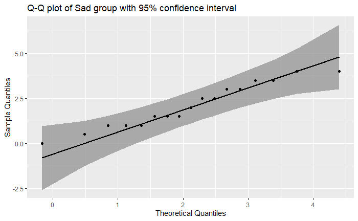

```r
ggplot(data = sad_df, mapping = aes(sample = Price)) +
    stat_qq_band(conf = 0.95) +
    stat_qq_line() +
    stat_qq_point() +
    labs(x = "Theoretical Quantiles", y = "Sample Quantiles")+ggtitle("Q-Q plot of Sad group with 95% confidence interval")
```

*From the normal quantile plot, we can see that all the data points lies pretty close to a central straight line and within the confidence interval band.*

#### Using probplot from e1071

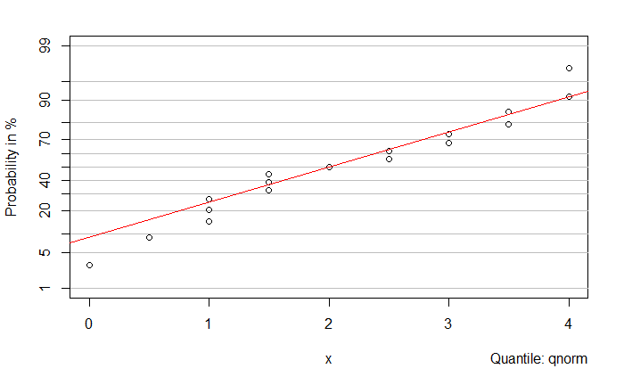

```r
# Normal probability plot of Sad group
probplot(x)
```

```r
# Anderson-Darling test
ad.test(x)
```

```
    Anderson-Darling normality test

data:  x
A = 0.34678, p-value = 0.4374
```

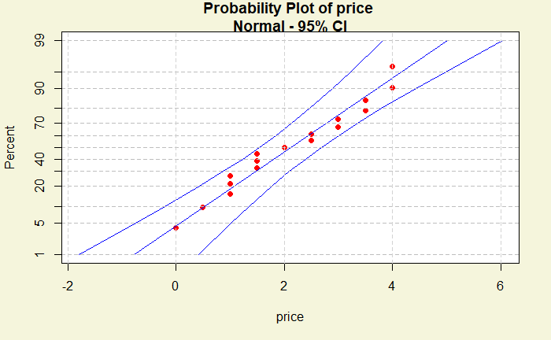

```r
minitab_normal_prob_plot(x, 'price')
```

*Again, from the normal probability plot, we can see that all the data points lies pretty close to a central straight line.* *So, based on the graphs above, the dataset of the price of purchasing insulated water bottle for the sad group follows normal distribution.*

```r
# For neutral group
neutral_df = filter(df,Group == 'N')
x = neutral_df$Price
summary(neutral_df)
```

```
     Price           Group
 Min.   :0.0000   Length:14
 1st Qu.:0.0000   Class :character
 Median :0.2500   Mode  :character
 Mean   :0.5714
 3rd Qu.:1.0000
 Max.   :2.0000
```

```r
sd(neutral_df$Price)
```

```
[1] 0.7300459
```

#### Using ggplot2

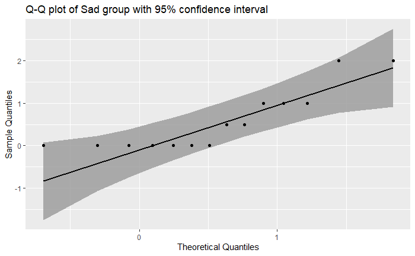

```r
ggplot(data = neutral_df, mapping = aes(sample = Price)) +
    stat_qq_band(conf = 0.95) +
    stat_qq_line() +
    stat_qq_point() +
    labs(x = "Theoretical Quantiles", y = "Sample Quantiles")+ggtitle("Q-Q plot of Sad group with 95% confidence interval")
```

#### Using probplot from e1071

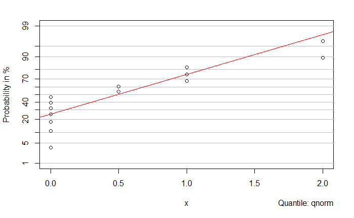

```r
# Normal probability plot of neutral group
probplot(x)
```

```r
# Anderson-Darling test
ad.test(x)
```

```
    Anderson-Darling normality test

data:  x
A = 1.2788, p-value = 0.001584
```

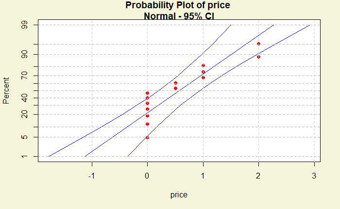

```r
minitab_normal_prob_plot(x, 'price')
```

*As we are trying to determine if there is a significant difference between the means price of purchasing insulated water bottles of two groups, use of t-procedures is appropriate.*

## B) Solution:

```r
group_df = df%>% group_by(Group) %>%  summarise(count = n(), mean = round(mean(Price),3), st_dev = round(sd(Price),3))
group_df
```

| Group | count | mean | st_dev |
| --- | --- | --- | --- |
| N | 14 | 0.571 | 0.730 |
| S | 17 | 2.118 | 1.244 |

## C) Solution:

It is appropriate to test whether there is any sufficient significant difference of the mean price of purchasing insulated water bottles for the neutral group and sad group.

The null Hypothesis: H0: There is no sufficient significant difference of the mean price of purchasing insulated water bottles for the neutral group and sad group.

So, H0: u1 = u2

Alternate hypothesis: H1: There is sufficient significant difference of the mean price of purchasing insulated water bottles for the neutral group and sad group.

So, H1: u1 <> u2

## D) Solution:

```r
# Here
x1 = group_df[1,3]
x2 = group_df[2,3]
s1 = group_df[1,4]
s2 = group_df[2,4]
n1 = group_df[1,2]
n2 = group_df[2,2]

t = (x1-x2)/sqrt((s1^2/n1)+(s2^2/n2))
t_cal = t$mean
paste("T-value",round(t_cal,4))
```

```
[1] "T-value -4.3056"
```

```r
d_f = min(n1-1, n2-1)
paste("Degrees of freedom",d_f)
```

```
[1] "Degrees of freedom 13"
```

```r
# P-value = 2*(t> T-value calculated)
#         = 1 - 2*(t<= T-value calculated)
2*pt(q=t_cal, df = d_f, lower.tail = T)
```

```
[1] 0.0008543538
```

*As the P-value is less than a = .05 we can reject the null hypothesis. We can say that there exists statistically significant evidence.* *To conclude, there is sufficient significant difference of the mean price of purchasing insulated water bottles for the neutral group and sad group.* *So, H1: u1 <> u2*

```r
# t critical value for 5% level of significance for a two tailed test
t_crit = qt(p=.05/2, df=13, lower.tail=FALSE)
t_crit
```

```
[1] 2.160369
```

## E) Solution:

```r
# 95% confidence interval for the mean difference in purchase price between the two groups
left_ci = (x1-x2) - (t_crit)*sqrt((s1^2/n1) + (s2^2/n2))
right_ci = (x1-x2) + (t_crit)*sqrt((s1^2/n1) + (s2^2/n2))
paste0('(', round(left_ci,3),', ',round(right_ci,3),')')
```

```
[1] "(-2.323, -0.771)"
```

# 7.90

## Revisiting the sadness and spending study

```r
# Test statistics for an unpaired t test with two tails and 95% level of confidence with assumed equal variance for pooled method
t_test <- t.test(Price ~ Group, data = df, mu=0, paired=FALSE,alternative="two.sided", conf.level = .95, var.equal = T)
t_test
```

```
    Two Sample t-test

data:  Price by Group
t = -4.0982, df = 29, p-value = 0.0003062
alternative hypothesis: true difference in means between group N and group S is not equal to 0
95 percent confidence interval:
 -2.3178661 -0.7745709
sample estimates:
mean in group N mean in group S
      0.5714286       2.1176471
```

```r
# 95% confidence interval for the mean difference in purchase price between the two groups
t_test[4]
```

```
$conf.int
[1] -2.3178661 -0.7745709
attr(,"conf.level")
[1] 0.95
```

*As the P-value from the t-test is less than a = .05 and since the confidence interval does not contain zero we can reject the null hypothesis. We can say that there exists statistically significant evidence.* *To conclude, there is sufficient significant difference of the mean price of purchasing insulated water bottles for the neutral group and sad group.* *So, H1: u1 <> u2*

# 7.125

## Interracial friendships in college

## A) Solution:

*Even though proportions are not normally distributed, it may still be appropriate to use the t procedures for these data due to larger sample sizes of average proportions which are greater than or equal to 40.*

## B) Solution:

*Test the difference between the two groups in the middle of first year and in the middle of third year.*

*From the given scenario, te null and the alternate hypotheses are as follows:*

Middle of first year: H0: uB = uW H1: uB <> uW

Middle of third year: H0: uB = uW H1: uB <> uW

## C) Solution:

### Middle of first year:

```r
# Here
uB = 0.085
uW = 0.063
s1 = 0.134
s2 = 0.112
n1 = 41
n2 = 197

t = (uB-uW)/sqrt((s1^2/n1)+(s2^2/n2))

paste("T-value",round(t,4))
```

```
[1] "T-value 0.9823"
```

```r
d_f = floor((s1^2/n1 + s2^2/n2)^2/((s1^2/n1)^2/(n1-1) + (s2^2/n2)^2/(n2-1)))
paste("Degrees of freedom",d_f)
```

```
[1] "Degrees of freedom 52"
```

```r
# P-value = 2*(t> T-value calculated)
#         = 1 - 2*(t<= T-value calculated)
p = 2*pt(q=t, df = d_f, lower.tail = F)
paste("P-value",p)
```

```
[1] "P-value 0.330513336195948"
```

```r
# t critical value for 5% level of significance for a two tailed test
t_crit = qt(p=.05/2, df=d_f, lower.tail=FALSE)
t_crit
```

```
[1] 2.006647
```

```r
# 95% confidence interval for the mean difference in purchase price between the two groups
left_ci = (uB-uW) - (t_crit)*sqrt((s1^2/n1) + (s2^2/n2))
right_ci = (uB-uW) + (t_crit)*sqrt((s1^2/n1) + (s2^2/n2))
paste0('(', round(left_ci,3),', ',round(right_ci,3),')')
```

```
[1] "(-0.023, 0.067)"
```

### Middle of third year:

```r
# Here
uB = 0.146
uW = 0.062
s1 = 0.243
s2 = 0.154
n1 = 41
n2 = 197

t = (uB-uW)/sqrt((s1^2/n1)+(s2^2/n2))

paste("T-value",round(t,4))
```

```
[1] "T-value 2.1263"
```

```r
d_f = floor((s1^2/n1 + s2^2/n2)^2/((s1^2/n1)^2/(n1-1) + (s2^2/n2)^2/(n2-1)))
paste("Degrees of freedom",d_f)
```

```
[1] "Degrees of freedom 46"
```

```r
# P-value = 2*(t> T-value calculated)
#         = 1 - 2*(t<= T-value calculated)
p = 2*pt(q=t, df = d_f, lower.tail = F)
paste("P-value",p)
```

```
[1] "P-value 0.0388724209875623"
```

```r
# t critical value for 5% level of significance for a two tailed test
t_crit = qt(p=.05/2, df=d_f, lower.tail=FALSE)
t_crit
```

```
[1] 2.012896
```

```r
# 95% confidence interval for the mean difference in purchase price between the two groups
left_ci = (uB-uW) - (t_crit)*sqrt((s1^2/n1) + (s2^2/n2))
right_ci = (uB-uW) + (t_crit)*sqrt((s1^2/n1) + (s2^2/n2))
paste0('(', round(left_ci,3),', ',round(right_ci,3),')')
```

```
[1] "(0.004, 0.164)"
```

## D) Solution:

### Decision for middle of first year:

*The P-value in context is greater than 0.05 (level of significance). So we cannot reject the null hypothesis. There is insufficient evidence to indicate that there is a difference in the average between black roommate and white roommate in the middle of first year. The result is not statistically significant.*

### Decision for middle of third year:

*The P-value in context is less than 0.05 (level of significance). So we can reject the null hypothesis. There is sufficient evidence to indicate that there is a difference in the average between black roommate and white roommate in the middle of third year. The result is statistically significant.*

# 7.140

## A) Solution:

*The data is given in the format of x̅± se.* *By definitions, ‘se’ standard mean of error which is calculated by se = S/√n* So, S = se * √n

```r
# Here from the given data
u1D = 2821 # Total calories Driver
u1C = 2844 # Total calories Conductor
u2D = .24 # Alcohol (grams) Driver
u2C = .39 # Alcohol (grams) Conductor
nD = 98 # Sample size of Driver
nC = 83 # Sample size of Conductor
se1D = 44 # standard mean of error for total calories of Driver
se1C = 48 # standard mean of error for total calories of Conductor
se2D = 0.06 # standard mean of error for Alcohol (grams) consumption of Driver
se2C = 0.11 # standard mean of error for Alcohol (grams) consumption of Conductor
s1D = se1D*sqrt(nD) # standard deviation for total calories of Driver
s2D = se2D*sqrt(nD) # standard deviation for Alcohol (grams) consumption of Driver
s1C = se1C*sqrt(nC) # standard deviation for total calories of Conductor
s2C = se2C*sqrt(nC) # standard deviation for Alcohol (grams) consumption of Conductor
s1D
```

```
[1] 435.5778
```

```r
s1C
```

```
[1] 437.3008
```

```r
s2D
```

```
[1] 0.5939697
```

```r
s2C
```

```
[1] 1.002148
```

## B) Solution:

*Let’s assume that the two samples are from a normal population.*

*Here we have to test whether there is enough evidence to claim that conductors consume more calories per day than drivers do.*

So our null hypothesis, H0: u1D = u1C Alternate hypothesis, H1: u1D < u1C

```r
# Under the null hypothesis
t = (u1D-u1C)/sqrt((s1D^2/nD)+(s1C^2/nC))

paste("T-value",round(t,4))
```

```
[1] "T-value -0.3532"
```

```r
d_f = floor((s1D^2/nD + s1C^2/nC)^2/((s1D^2/nD)^2/(nD-1) + (s1C^2/nC)^2/(nC-1)))
paste("Degrees of freedom",d_f)
```

```
[1] "Degrees of freedom 173"
```

```r
# P-value for one tailed test for lower tail
# P-value = (t< T-value calculated)
p = pt(q=t, df = d_f, lower.tail = T)
paste("P-value",round(p,4))
```

```
[1] "P-value 0.3622"
```

*As the P-value is greater than a = 0.05 level of significance, we fail to reject the null hypothesis.* *Therefore, there is no evidence to conclude that conductors consume more calories per day than drivers.*

```r
# t critical value for 5% level of significance for a one tailed test
t_crit = qt(p=.05, df=d_f, lower.tail=T)
t_crit
```

```
[1] -1.653709
```

```r
# 95% confidence interval for the mean difference in total calories consumption between the two groups
left_ci = (u1D-u1C) - (t_crit)*sqrt((s1D^2/nD) + (s1C^2/nC))
right_ci = (u1D-u1C) + (t_crit)*sqrt((s1D^2/nD) + (s1C^2/nC))
paste0('(', round(left_ci,3),', ',round(right_ci,3),')')
```

```
[1] "(84.682, -130.682)"
```

#### Alternate solution:

```r
tsum.test(mean.x=u1D, s.x=s1D, n.x=nD,
          mean.y=u1C, s.y=s1C, n.y=nC,alternative = "less",  mu = 0,  var.equal = FALSE,  conf.level = 0.95)
```

```
    Welch Modified Two-Sample t-Test

data:  Summarized x and y
t = -0.35322, df = 173.9, p-value = 0.3622
alternative hypothesis: true difference in means is less than 0
95 percent confidence interval:
       NA 84.67873
sample estimates:
mean of x mean of y
     2821      2844
```

## C) Solution:

*Let’s assume that the two samples are from a normal population.*

*Here we have to test whether there is a significant evidence of mean difference in alcohol consumption between drivers and conductors.*

So our null hypothesis, H0: u2D = u2C Alternate hypothesis, H1: u2D ≠ u2C

```r
# Under the null hypothesis
t = (u2D-u2C)/sqrt((s2D^2/nD)+(s2C^2/nC))

paste("T-value",round(t,4))
```

```
[1] "T-value -1.1971"
```

```r
d_f = floor((s2D^2/nD + s2C^2/nC)^2/((s2D^2/nD)^2/(nD-1) + (s2C^2/nC)^2/(nC-1)))
paste("Degrees of freedom",d_f)
```

```
[1] "Degrees of freedom 128"
```

```r
# P-value for one tailed test for lower tail
# P-value = (t< T-value calculated)
p = 2*pt(q=t, df = d_f, lower.tail = T)
paste("P-value",round(p,4))
```

```
[1] "P-value 0.2335"
```

#### Alternate solution:

```r
alc_test_95 = tsum.test(mean.x=u2D, s.x=s2D, n.x=nD,
          mean.y=u2C, s.y=s2C, n.y=nC,alternative = "two.sided",  mu = 0,  var.equal = FALSE,  conf.level = 0.95)
alc_test_95
```

```
    Welch Modified Two-Sample t-Test

data:  Summarized x and y
t = -1.1971, df = 128.44, p-value = 0.2335
alternative hypothesis: true difference in means is not equal to 0
95 percent confidence interval:
 -0.39791863  0.09791863
sample estimates:
mean of x mean of y
     0.24      0.39
```

## D) Solution:

```r
cal_test_05 = tsum.test(mean.x=u1D, s.x=s1D, n.x=nD,
          mean.y=u1C, s.y=s1C, n.y=nC,alternative = "two.sided",  mu = 0,  var.equal = FALSE,  conf.level = 0.95)
```

```r
# 95% confidence interval for the difference in mean daily calories consumption between drivers and conductors
cal_test_05[4]
```

```
$conf.int
[1] -151.518  105.518
attr(,"conf.level")
[1] 0.95
```

```r
# 95% confidence interval for the difference in mean daily alcohol consumption between drivers and conductors
alc_test_95[4]
```

```
$conf.int
[1] -0.39791863  0.09791863
attr(,"conf.level")
[1] 0.95
```

## E) Solution:

```r
alc_test_99 = tsum.test(mean.x=u2D, s.x=s2D, n.x=nD,
          mean.y=u2C, s.y=s2C, n.y=nC,alternative = "two.sided",  mu = 0,  var.equal = FALSE,  conf.level = 0.99)
alc_test_99
```

```
    Welch Modified Two-Sample t-Test

data:  Summarized x and y
t = -1.1971, df = 128.44, p-value = 0.2335
alternative hypothesis: true difference in means is not equal to 0
99 percent confidence interval:
 -0.4776146  0.1776146
sample estimates:
mean of x mean of y
     0.24      0.39
```

```r
# 99% confidence interval for the difference in mean daily alcohol consumption between drivers and conductors
alc_test_99[4]
```

```
$conf.int
[1] -0.4776146  0.1776146
attr(,"conf.level")
[1] 0.99
```